# The Quantification of Replicability with RepliBayes: an illustrative example

> **Note.** Building this vignette fits several Stan models and takes a few minutes (and needs a C++ compiler; see below). To read it quickly without rebuilding, open the pre-built HTML.

# What this package does

`RepliBayes` implements the Bayesian framework of Alongi, Altoè and Parmigiani, *The Quantification of Replicability*. Suppose the same effect has been studied in several studies. Instead of the yes/no question “did it reach statistical significance again?”, the framework asks a graded question:

> **How probable is it that the studies agree the effect is real and practically relevant?**

It answers with **posterior probabilities**, defined relative to a practical-relevance threshold `eps` on the *scale of the effect itself*, from one Bayesian hierarchical model:

$$y_{si}\sim \mathcal N(\alpha_s + \beta_s\,x_{si},\ \sigma_s^2),\qquad
\beta_s\sim t_3(\beta,\tau_\beta),\quad
\alpha_s\sim t_3^{+}(\alpha,\tau_\alpha),\quad
\sigma_s\sim t_3^{+}(\sigma,\tau_\sigma),$$

for studies $s = 1,\dots,S$. $\beta_s$ is the effect in study $s$, $\beta$ the shared **generative** effect, and $\tau_\beta$ how much the studies differ. A study effect is *positive* if $\beta_s>\varepsilon$, *negative* if $\beta_s<-\varepsilon$, *null* if $|\beta_s|\le\varepsilon$; “replication at consensus level $k$” means at least $k$ of the $S$ studies fall in the same category.

This tutorial reproduces the whole analysis on a small **synthetic** dataset shipped with the package. It assumes no prior knowledge of R.

# Installing everything from scratch

You do this once.

**1. Install R** from cran.r-project.org (and, optionally, [RStudio](https://posit.co/download/rstudio-desktop/)).

**2. Install a C++ compiler** (needed by Stan, which `RepliBayes` uses): Windows → [Rtools](https://cran.r-project.org/bin/windows/Rtools/); macOS → run `xcode-select --install` in Terminal; Linux → system `g++`.

**3. Install `rstan` and the packages used for the plots:**

```r
install.packages(c("rstan", "ggplot2", "patchwork", "knitr", "remotes"))
```

**4. Install `RepliBayes`:**

```r
remotes::install_github("esteralongi/RepliBayes", build_vignettes = TRUE)
```

Everything below is runnable R code; the `#>` lines are what R prints back, and the numerical results are shown as tables.

# Load the package and the data

```r
library(rstan)
library(ggplot2)
library(patchwork)
library(RepliBayes)
set.seed(42)

## small helper: render a data frame / matrix as a table
show_tbl <- function(x, digits = 3, caption = NULL)
  knitr::kable(x, digits = digits, caption = caption)

## a consistent colour palette used throughout
study_cols <- c("Study 1" = "#0072B2", "Study 2" = "#009E73", "Study 3" = "#E69F00")
gen_col <- "#2C3E50"; prior_col <- "grey50"; obs_col <- "#0072B2"; pred_col <- "#A51C30"
```

```r
data(synthetic_data)         # columns: study, x, y
show_tbl(head(synthetic_data), caption = "First rows of the synthetic data")
```

First rows of the synthetic data

| study | x | y |
| --- | --- | --- |
| 1 | 0 | 11.028 |
| 1 | 0 | 12.711 |
| 1 | 0 | 13.572 |
| 1 | 1 | 10.992 |
| 1 | 0 | 3.946 |
| 1 | 0 | -2.197 |

```r
show_tbl(as.data.frame(table(synthetic_data$study),
                       responseName = "n"),
         caption = "Number of observations per study",
         digits = 0)
```

Number of observations per study

| Var1 | n |
| --- | --- |
| 1 | 120 |
| 2 | 600 |
| 3 | 350 |

# The priors

`default_priors()` returns the illustrative hyperparameters used in the paper (`beta` = effect, `alpha` = intercept, `sig` = residual scale, and the three `tau_*` heterogeneities). Copy the list and edit any field to use your own.

```r
priors <- default_priors()
nu <- priors$nu
show_tbl(data.frame(hyperparameter = names(unlist(priors)),
                    value = unlist(priors), row.names = NULL),
         caption = "Elicited prior hyperparameters")
```

Elicited prior hyperparameters

| hyperparameter | value |
| --- | --- |
| nu | 3.00 |
| mu_beta | 0.05 |
| scale_beta | 0.60 |
| mu_alpha | 8.50 |
| scale_alpha | 3.00 |
| mu_sig | 4.50 |
| scale_sig | 2.00 |
| mu_tau_beta | -1.00 |
| scale_tau_beta | 0.30 |
| mu_tau_alpha | -1.30 |
| scale_tau_alpha | 0.40 |
| mu_tau_sig | -1.00 |
| scale_tau_sig | 0.28 |

What these priors imply (simulated draws; `rtrunc_t_pos()` draws from a positive Student-$t$):

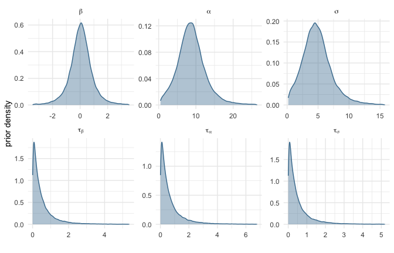

```r
N <- 40000
pri <- data.frame(
  value = c(
    priors$mu_beta  + priors$scale_beta  * rt(N, nu),
    rtrunc_t_pos(N, nu, priors$mu_alpha,     priors$scale_alpha),
    rtrunc_t_pos(N, nu, priors$mu_sig,       priors$scale_sig),
    rtrunc_t_pos(N, nu, priors$mu_tau_beta,  priors$scale_tau_beta),
    rtrunc_t_pos(N, nu, priors$mu_tau_alpha, priors$scale_tau_alpha),
    rtrunc_t_pos(N, nu, priors$mu_tau_sig,   priors$scale_tau_sig)),
  param = factor(rep(c("beta","alpha","sigma","tau[beta]","tau[alpha]","tau[sigma]"),
                     each = N),
                 levels = c("beta","alpha","sigma","tau[beta]","tau[alpha]","tau[sigma]")))
keep <- ave(pri$value, pri$param,
            FUN = function(v) v >= quantile(v,.005) & v <= quantile(v,.995)) == 1
ggplot(pri[keep,], aes(value)) +
  geom_density(fill = "#457B9D", colour = "#457B9D", alpha = .4) +
  facet_wrap(~ param, scales = "free", labeller = label_parsed) +
  labs(x = "", y = "prior density") + theme_minimal(base_size = 11)
```

# The whole analysis in one call

```r
res <- fit_replicability(
  synthetic_data, priors = priors, consensus_level = 2, min_corroborating = 1,
  chains = 2, iter = 3000, verbose = FALSE
)
```

```r
res                          # compact overview (studies, eps, a few metrics)
```

```
#> <RepliBayes>
#>   studies: 1, 2, 3  (S = 3)
#>   eps    : 0.9129   consensus_level = 2   min_corroborating = 1
#>   hierarchical (selected metrics):
#>     P_overall_2        1.000 +/- 0.000
#>     P_non_null_2       0.523 +/- 0.011
#>     P_beta             0.445 +/- 0.012
#>     P_gen_overall_2    0.804 +/- 0.009
#>   also computed: prospective (evidence: 1, 2, 3); retrospective (target: 1; evidence: 2, 3)
#>   see $metrics_hierarchical, $metrics_independence, $metrics_prospective, $metrics_retrospective
```

# Posterior diagnostics: looking at the chains

`res$fit_hierarchical` is a full `stanfit` object, so you can inspect the MCMC chains directly. Sampling is healthy when there are no divergences, split-$\widehat R$ is close to 1, and the effective sample sizes are adequate.

```r
pars <- c("mu_beta", "tau_beta", "tau_alpha", "tau_sig", "mu_alpha", "mu_sig")
rstan::check_hmc_diagnostics(res$fit_hierarchical)
```

```
#>
#> Divergences:
#>
#> Tree depth:
#>
#> Energy:
```

```r
show_tbl(rstan::summary(res$fit_hierarchical, pars = pars)$summary[, c("Rhat", "n_eff")],
         caption = "Hierarchical model: split-Rhat and effective sample size")
```

Hierarchical model: split-Rhat and effective sample size

|  | Rhat | n_eff |
| --- | --- | --- |
| mu_beta | 1.001 | 1272.477 |
| tau_beta | 1.003 | 1202.132 |
| tau_alpha | 1.000 | 1045.313 |
| tau_sig | 1.000 | 878.162 |
| mu_alpha | 1.001 | 1306.465 |
| mu_sig | 1.005 | 627.523 |

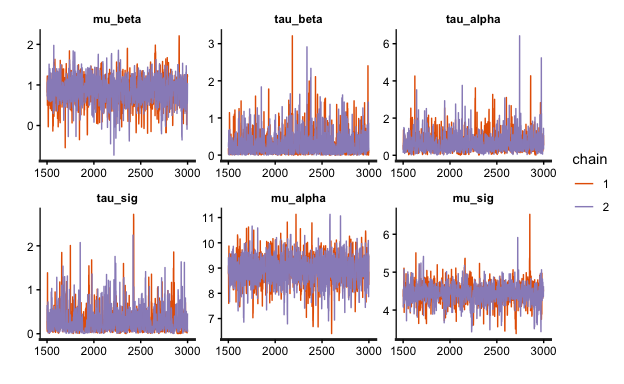

```r
rstan::traceplot(res$fit_hierarchical, pars = pars)
```

The trace plot draws one coloured line per chain; well-mixed chains overlap like a “fuzzy caterpillar”. To get the raw draws with the **chains kept separate**, use `permuted = FALSE` (plain `rstan::extract()` merges them):

```r
arr <- rstan::extract(res$fit_hierarchical, pars = "mu_beta", permuted = FALSE)
dim(arr)                 # iterations x chains x parameters
```

```
#> [1] 1500    2    1
```

```r
show_tbl(arr[1:3, , "mu_beta"], caption = "First 3 iterations of each chain (mu_beta)")
```

First 3 iterations of each chain (mu_beta)

| chain:1 | chain:2 |
| --- | --- |
| 0.813 | 0.717 |
| 1.177 | 0.780 |
| 1.220 | 1.046 |

The independence-limit fit is checked the same way (it has no `tau_*` parameters):

```r
rstan::check_hmc_diagnostics(res$fit_independence)
```

```
#>
#> Divergences:
#>
#> Tree depth:
#>
#> Energy:
```

```r
show_tbl(rstan::summary(res$fit_independence,
                        pars = c("mu_beta", "mu_alpha", "mu_sig"))$summary[, c("Rhat", "n_eff")],
         caption = "Independence-limit model: split-Rhat and effective sample size")
```

Independence-limit model: split-Rhat and effective sample size

|  | Rhat | n_eff |
| --- | --- | --- |
| mu_beta | 1.000 | 1235.860 |
| mu_alpha | 1.003 | 1353.132 |
| mu_sig | 1.001 | 1800.367 |

# Reading the metrics

Each row is a metric; `estimate` is the posterior probability and `mcse` its Monte Carlo error (`n_event`, `n_draws`, `ess` are the count, sample size and effective sample size behind each probability).

```r
show_tbl(res$metrics_hierarchical,
         caption = "Hierarchical model: replication probabilities with MCSE")
```

Hierarchical model: replication probabilities with MCSE

| metric | estimate | n_event | n_draws | ess | mcse |
| --- | --- | --- | --- | --- | --- |
| P_overall_2 | 1.000 | 2999 | 3000 | 3000.000 | 0.000 |
| P_non_null_2 | 0.523 | 1569 | 3000 | 2167.119 | 0.011 |
| P_pos_2 | 0.523 | 1569 | 3000 | 2167.119 | 0.011 |
| P_neg_2 | 0.000 | 0 | 3000 | NA | NA |
| P_null_2 | 0.477 | 1430 | 3000 | 2164.461 | 0.011 |
| P_cond_O1_m1 | 0.924 | 1280 | 1385 | 1385.000 | 0.007 |
| P_cond_O2_m1 | 0.925 | 1226 | 1325 | 1325.000 | 0.007 |
| P_cond_O3_m1 | 0.727 | 1483 | 2039 | 2039.000 | 0.010 |
| P_beta | 0.445 | 1335 | 3000 | 1634.855 | 0.012 |
| P_gen_overall_2 | 0.804 | 2411 | 3000 | 1890.594 | 0.009 |
| P_gen_non_null_2 | 0.386 | 1158 | 3000 | 1751.886 | 0.012 |
| P_gen_pos_2 | 0.386 | 1158 | 3000 | 1751.886 | 0.012 |
| P_gen_neg_2 | 0.000 | 0 | 3000 | NA | NA |
| P_gen_null_2 | 0.418 | 1253 | 3000 | 1924.953 | 0.011 |
| P_c_pos_2 | 0.867 | 1158 | 1335 | 1335.000 | 0.009 |
| P_c_neg_2 | NA | 0 | 0 | NA | NA |
| P_c_null_2 | 0.753 | 1253 | 1665 | 1665.000 | 0.011 |

```r
show_tbl(res$metrics_independence,
         caption = "Independence limit: replication probabilities with MCSE")
```

Independence limit: replication probabilities with MCSE

| metric | estimate | n_event | n_draws | ess | mcse |
| --- | --- | --- | --- | --- | --- |
| P_overall_2 | 1.000 | 3000 | 3000 | NA | NA |
| P_non_null_2 | 0.661 | 1983 | 3000 | 2833.652 | 0.009 |
| P_pos_2 | 0.661 | 1983 | 3000 | 2833.652 | 0.009 |
| P_neg_2 | 0.000 | 0 | 3000 | NA | NA |
| P_null_2 | 0.339 | 1017 | 3000 | 2833.652 | 0.009 |
| P_cond_O1_m1 | 0.874 | 1722 | 1970 | 1970.000 | 0.007 |
| P_cond_O2_m1 | 0.924 | 950 | 1028 | 1028.000 | 0.008 |
| P_cond_O3_m1 | 0.765 | 1834 | 2396 | 2396.000 | 0.009 |

Names (with `S = 3`, `consensus_level = 2`): `P_overall_2` = at least 2 studies agree; `P_pos_2`/`P_neg_2`/`P_null_2` = at least 2 positive/negative/null; `P_cond_O1_m1` = given study 1 detects, it agrees with $\ge 1$ other study; `P_beta` = $P(|\beta|>\varepsilon)$; `P_gen_*` add consistency with the sign of the generative effect; `P_c_*` are conditional on that sign.

# Posterior of the effects

## Independence limit

Posterior densities of the three study effects with the (near-flat) prior overlaid; dotted lines mark $\pm\varepsilon$.

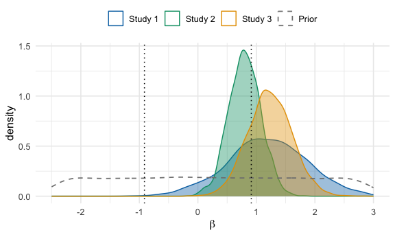

```r
lev <- c(study_labels, "Prior"); pal <- c(study_cols, "Prior" = prior_col)
xr  <- c(-2.5, 3)
tau_fix  <- qt_trunc_scaled_vec(0.999, nu, priors$mu_tau_beta, priors$scale_tau_beta)
beta_i0  <- priors$mu_beta + priors$scale_beta * rt(40000, nu)
prior_i  <- beta_i0 + tau_fix * rt(40000, nu)                    # independence-limit prior

df_post  <- data.frame(a = as.vector(post_i$beta),
                       study = factor(rep(study_labels, each = nrow(post_i$beta)), levels = lev))
df_prior <- data.frame(a = prior_i, study = factor("Prior", levels = lev))
clip <- function(d) subset(d, a >= xr[1] & a <= xr[2])
ggplot() +
  geom_density(data = clip(df_post),  aes(a, color = study, fill = study),
               alpha = .4, linewidth = .5) +
  geom_density(data = clip(df_prior), aes(a, color = study),
               linewidth = .6, linetype = "dashed") +
  scale_color_manual(values = pal) + scale_fill_manual(values = pal, guide = "none") +
  geom_vline(xintercept = c(-eps, eps), linetype = "dotted") +
  coord_cartesian(xlim = xr) +
  labs(x = expression(beta), y = "density", color = NULL) +
  theme_minimal(base_size = 12) + theme(legend.position = "top")
```

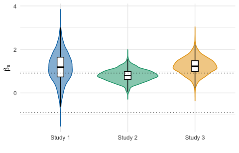

```r
dfv <- data.frame(a = as.vector(post_i$beta),
                  study = factor(rep(study_labels, each = nrow(post_i$beta)),
                                 levels = study_labels))
ggplot(dfv, aes(study, a, fill = study, color = study)) +
  geom_violin(trim = FALSE, alpha = .5) +
  geom_boxplot(width = .1, fill = "white", color = "black", outlier.shape = NA) +
  geom_hline(yintercept = c(-eps, eps), linetype = "dotted") +
  scale_color_manual(values = study_cols) + scale_fill_manual(values = study_cols) +
  labs(x = "", y = expression(beta[s])) +
  theme_minimal(base_size = 11) + theme(legend.position = "none")
```

## Hierarchical model

The three study effects, the generative effect $\beta$, and the (correlated) prior:

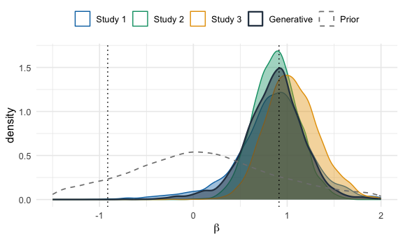

```r
lev_h <- c(study_labels, "Generative", "Prior")
pal_h <- c(study_cols, "Generative" = gen_col, "Prior" = prior_col)
xr_h  <- c(-1.5, 2)
tau_b   <- rtrunc_t_pos(40000, nu, priors$mu_tau_beta, priors$scale_tau_beta)
beta_h0 <- priors$mu_beta + priors$scale_beta * rt(40000, nu)
prior_h <- beta_h0 + tau_b * rt(40000, nu)                       # hierarchical prior
mu_prior <- beta_h0

df_ph <- data.frame(a = as.vector(post_h$beta),
                    study = factor(rep(study_labels, each = nrow(post_h$beta)), levels = lev_h))
df_mu <- data.frame(a = post_h$mu_beta, study = factor("Generative", levels = lev_h))
df_pr <- data.frame(a = prior_h,        study = factor("Prior", levels = lev_h))
clh <- function(d) subset(d, a >= xr_h[1] & a <= xr_h[2])
ggplot() +
  geom_density(data = clh(df_ph), aes(a, color = study, fill = study), alpha = .4, linewidth = .5) +
  geom_density(data = clh(df_mu), aes(a, color = study, fill = study), alpha = .5, linewidth = .8) +
  geom_density(data = clh(df_pr), aes(a, color = study), linewidth = .6, linetype = "dashed") +
  scale_color_manual(values = pal_h, breaks = lev_h) +
  scale_fill_manual(values = pal_h, breaks = lev_h, guide = "none") +
  geom_vline(xintercept = c(-eps, eps), linetype = "dotted") +
  coord_cartesian(xlim = xr_h) +
  labs(x = expression(beta), y = "density", color = NULL) +
  theme_minimal(base_size = 12) + theme(legend.position = "top")
```

The generative effect $\beta$, prior vs posterior:

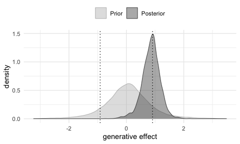

```r
xrm <- as.numeric(quantile(c(mu_prior, post_h$mu_beta), c(.005, .995)))
dfm <- data.frame(value = c(mu_prior, post_h$mu_beta),
                  type = factor(rep(c("Prior","Posterior"),
                                    c(length(mu_prior), length(post_h$mu_beta))),
                                levels = c("Prior","Posterior")))
ggplot(subset(dfm, value >= xrm[1] & value <= xrm[2]), aes(value, color = type, fill = type)) +
  geom_density(alpha = .4, linewidth = .3) +
  geom_vline(xintercept = c(-eps, eps), linetype = "dotted") +
  scale_color_manual(values = c(Prior = "gray70", Posterior = "gray20")) +
  scale_fill_manual(values  = c(Prior = "gray70", Posterior = "gray20")) +
  coord_cartesian(xlim = xrm) +
  labs(x = "generative effect", y = "density", color = NULL, fill = NULL) +
  theme_minimal(base_size = 11) + theme(legend.position = "top")
```

# Metric names and labels

```r
metrics_k2 <- c("P_overall_2","P_non_null_2","P_pos_2","P_null_2","P_neg_2",
                "P_cond_O1_m1","P_cond_O2_m1","P_cond_O3_m1","P_beta",
                "P_gen_overall_2","P_gen_non_null_2","P_gen_pos_2","P_gen_null_2",
                "P_gen_neg_2","P_c_pos_2","P_c_null_2","P_c_neg_2")
metrics_base <- metrics_k2[1:8]        # study-level metrics (independence limit)
lab <- c(
  P_overall_2="P['overall,2']", P_non_null_2="P['non-null,2']", P_pos_2="P['pos,2']",
  P_null_2="P['null,2']", P_neg_2="P['neg,2']",
  P_cond_O1_m1="P['cond|O1']", P_cond_O2_m1="P['cond|O2']", P_cond_O3_m1="P['cond|O3']",
  P_beta="P[beta]",
  P_gen_overall_2="P['gen,overall,2']", P_gen_non_null_2="P['gen,non-null,2']",
  P_gen_pos_2="P['gen,pos,2']", P_gen_null_2="P['gen,null,2']", P_gen_neg_2="P['gen,neg,2']",
  P_c_pos_2="P['c,pos,2']", P_c_null_2="P['c,null,2']", P_c_neg_2="P['c,neg,2']")
```

# From prior to posterior

A triangle marks the prior value of each metric and a dot the posterior; the triangle points up if the data raise the probability, down if they lower it. We recompute the metrics on prior draws with `compute_replication_probs_*()`.

```r
prior_indep <- compute_replication_probs_indep(list(prior_i, prior_i, prior_i),
                                               eps = eps, consensus_level = 2)
prior_hier  <- compute_replication_probs_hier(
  list(beta_h0 + tau_b*rt(40000,nu), beta_h0 + tau_b*rt(40000,nu), beta_h0 + tau_b*rt(40000,nu)),
  generative_beta = mu_prior, eps = eps, consensus_level = 2)

tri_plot <- function(prior_named, post_tbl, metrics, title) {
  post_p <- stats::setNames(post_tbl$estimate, post_tbl$metric)
  pri    <- unlist(prior_named)
  d <- data.frame(metric = metrics,
                  Prior = as.numeric(pri[metrics]), Posterior = as.numeric(post_p[metrics]))
  d <- d[!is.na(d$Prior) & !is.na(d$Posterior), ]
  d$metric <- factor(d$metric, levels = d$metric)
  long <- rbind(data.frame(metric = d$metric, p = d$Prior,     type = "Prior"),
                data.frame(metric = d$metric, p = d$Posterior, type = "Posterior"))
  long$shape <- ifelse(long$type == "Posterior", "Posterior",
                       ifelse(d$Prior[match(long$metric, d$metric)] <
                              d$Posterior[match(long$metric, d$metric)], "Prior_up", "Prior_down"))
  ggplot(long, aes(metric, p)) +
    geom_line(aes(group = metric), color = "grey70", linewidth = .4) +
    geom_point(aes(shape = shape), size = 2.2, color = "grey20", fill = "grey20") +
    scale_shape_manual(values = c(Posterior = 16, Prior_up = 24, Prior_down = 25),
                       breaks = c("Posterior","Prior_up"), labels = c("Posterior","Prior")) +
    scale_x_discrete(labels = function(x) parse(text = lab[x])) +
    ylim(0, 1) + labs(title = title, x = "", y = "probability", shape = NULL) +
    theme_minimal(base_size = 10) +
    theme(axis.text.x = element_text(angle = 45, hjust = 1),
          legend.position = "top", panel.grid.major.x = element_blank())
}
```

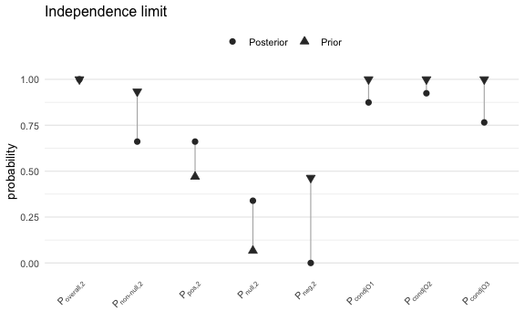

```r
tri_plot(prior_indep, res$metrics_independence, metrics_base, "Independence limit")
```

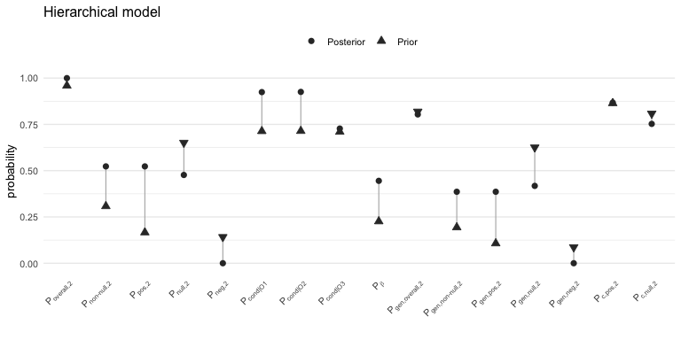

```r
tri_plot(prior_hier, res$metrics_hierarchical, metrics_k2, "Hierarchical model")
```

# Independence vs hierarchical

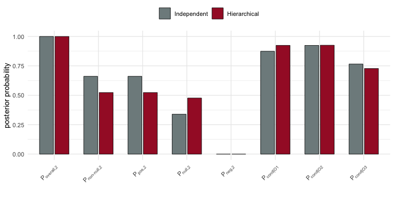

```r
shared <- intersect(res$metrics_independence$metric, res$metrics_hierarchical$metric)
dih <- rbind(
  data.frame(res$metrics_independence[res$metrics_independence$metric %in% shared,
                                      c("metric","estimate")], model = "Independent"),
  data.frame(res$metrics_hierarchical[res$metrics_hierarchical$metric %in% shared,
                                      c("metric","estimate")], model = "Hierarchical"))
dih$metric <- factor(dih$metric, levels = metrics_k2)
dih$model  <- factor(dih$model, levels = c("Independent","Hierarchical"))
ggplot(dih, aes(metric, estimate, fill = model)) +
  geom_col(position = position_dodge2(preserve = "single"), width = .7,
           colour = "black", linewidth = .3) +
  scale_fill_manual(values = c(Independent = "#7F8C8D", Hierarchical = "#A51C30")) +
  scale_x_discrete(labels = function(x) parse(text = lab[x])) +
  ylim(0, 1) + labs(x = "", y = "posterior probability", fill = NULL) +
  theme_minimal(base_size = 11) +
  theme(axis.text.x = element_text(angle = 45, hjust = 1), legend.position = "top")
```

# Threshold-free summaries

`replication_threshold_free()` needs no threshold: it reports the range of the study effects and their overlap (the grey area shared by all study posteriors; 1 = identical, 0 = disjoint).

```r
beta_i_list <- lapply(seq_len(S), function(s) post_i$beta[, s])
beta_h_list <- lapply(seq_len(S), function(s) post_h$beta[, s])
show_tbl(rbind(independent  = unlist(replication_threshold_free(beta_i_list)),
               hierarchical = unlist(replication_threshold_free(beta_h_list))),
         caption = "Threshold-free summaries: divergence and overlap")
```

Threshold-free summaries: divergence and overlap

|  | mean_max_divergence | sd_max_divergence | density_overlap |
| --- | --- | --- | --- |
| independent | 0.908 | 0.466 | 0.432 |
| hierarchical | 0.412 | 0.384 | 0.701 |

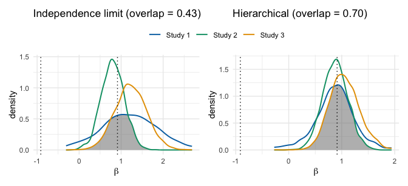

```r
overlap_plot <- function(beta_list, title) {
  xr   <- as.numeric(quantile(unlist(beta_list), c(.005, .995)))
  dens <- function(x) density(x, from = xr[1], to = xr[2], n = 512)
  g    <- dens(beta_list[[1]])$x
  ov   <- data.frame(a = g, y = Reduce(pmin, lapply(beta_list, function(x) dens(x)$y)))
  curves <- do.call(rbind, Map(function(x, s)
    data.frame(a = dens(x)$x, y = dens(x)$y, study = s), beta_list, study_labels))
  ov_val <- sum(ov$y) * (g[2] - g[1])
  ggplot() +
    geom_area(data = ov, aes(a, y), fill = "grey50", alpha = .55) +
    geom_line(data = curves, aes(a, y, color = study), linewidth = .7) +
    geom_vline(xintercept = c(-eps, eps), linetype = "dotted") +
    scale_color_manual(values = study_cols) +
    labs(title = sprintf("%s (overlap = %.2f)", title, ov_val),
         x = expression(beta), y = "density", color = NULL) +
    theme_minimal(base_size = 11) + theme(legend.position = "top")
}
overlap_plot(beta_i_list, "Independence limit") +
  overlap_plot(beta_h_list, "Hierarchical") +
  plot_layout(guides = "collect") & theme(legend.position = "top")
```

# Predictive replicability

## Retrospective: a left-out study

`fit_replicability()` already left out one study and predicted it from a body of evidence (the other studies). The agreement between the two effect distributions is what `res$metrics_retrospective` quantifies.

```r
cat(sprintf("target study: %s;  body of evidence: %s\n",
            res$retro_target, paste(res$retro_evidence, collapse = ", ")))
```

```
#> target study: 1;  body of evidence: 2, 3
```

```r
show_tbl(res$metrics_retrospective,
         caption = "Retrospective metrics (left-out study vs prediction)")
```

Retrospective metrics (left-out study vs prediction)

| metric | estimate | n_event | n_draws | ess | mcse |
| --- | --- | --- | --- | --- | --- |
| P_overall_l | 0.472 | 1417 | 3000 | 2510.797 | 0.010 |
| P_null_l | 0.201 | 602 | 3000 | 2669.154 | 0.008 |
| P_non_null_l | 0.272 | 815 | 3000 | 2295.652 | 0.009 |
| P_pos_l | 0.272 | 815 | 3000 | 2295.652 | 0.009 |
| P_neg_l | 0.000 | 0 | 3000 | NA | NA |

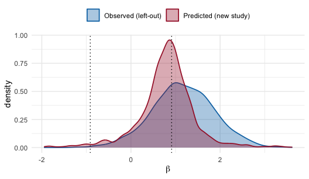

```r
a_hat <- predict_new_study(res$fit_retro_evidence, nu = nu, seed = 42)  # predicted new study
a_obs <- rstan::extract(res$fit_retro_obs)$beta[, 1]                    # observed left-out study
dfr <- data.frame(a = c(a_obs, a_hat),
                  type = rep(c("Observed (left-out)","Predicted (new study)"),
                             c(length(a_obs), length(a_hat))))
xrr <- as.numeric(quantile(dfr$a, c(.005, .995)))
ggplot(subset(dfr, a >= xrr[1] & a <= xrr[2]), aes(a, color = type, fill = type)) +
  geom_density(alpha = .35, linewidth = .6) +
  geom_vline(xintercept = c(-eps, eps), linetype = "dotted") +
  scale_color_manual(values = c("Observed (left-out)" = obs_col,
                                "Predicted (new study)" = pred_col)) +
  scale_fill_manual(values  = c("Observed (left-out)" = obs_col,
                                "Predicted (new study)" = pred_col)) +
  labs(x = expression(beta), y = "density", color = NULL, fill = NULL) +
  theme_minimal(base_size = 11) + theme(legend.position = "top")
```

## Prospective: a brand-new study

```r
cat(sprintf("body of evidence: %s\n", paste(res$pro_evidence, collapse = ", ")))
```

```
#> body of evidence: 1, 2, 3
```

```r
show_tbl(res$metrics_prospective,
         caption = "Prospective metrics (a new study from the full model)")
```

Prospective metrics (a new study from the full model)

| metric | estimate | n_event | n_draws | ess | mcse |
| --- | --- | --- | --- | --- | --- |
| P_non_null_p | 0.482 | 1446 | 3000 | 2191.971 | 0.011 |
| P_null_p | 0.518 | 1554 | 3000 | 2191.971 | 0.011 |
| P_pos_p | 0.467 | 1400 | 3000 | 2093.667 | 0.011 |
| P_neg_p | 0.015 | 46 | 3000 | 2835.888 | 0.002 |

# Prior sensitivity

We refit the analysis while shifting the prior median of $\tau_\beta$ across percentiles of its elicited prior (0.5 reproduces the main analysis). This refits the model once per setting; a reduced grid and short chains are used here so the tutorial builds.

```r
sens <- sensitivity_prior(
  synthetic_data, target = "tau_beta", consensus_level = 2, min_corroborating = 1,
  percentiles = c(0.10, 0.50, 0.90),
  chains = 2, iter_start = 800, iter_max = 1600, verbose = FALSE
)
```

Per-setting convergence, and the metric-by-prior-median grid:

```r
show_tbl(sens$grid, caption = "Prior sensitivity: per-setting convergence diagnostics")
```

Prior sensitivity: per-setting convergence diagnostics

| pctl | prior_med | post_med | iter_used | converged | max_rhat | min_ess |
| --- | --- | --- | --- | --- | --- | --- |
| 0.1 | 0.043 | 0.038 | 800 | 1 | 1.011 | 137.397 |
| 0.5 | 0.308 | 0.173 | 800 | 1 | 1.016 | 142.838 |
| 0.9 | 1.326 | 0.337 | 1600 | 0 | 1.020 | 241.027 |

```r
show_tbl(as.matrix(sens$p_grid)[metrics_k2, ],
         caption = "Point estimates by prior median of tau_beta (rows = metrics)")
```

Point estimates by prior median of tau_beta (rows = metrics)

|  | 0.043046907538022 | 0.307930200461278 | 1.32632397193003 |
| --- | --- | --- | --- |
| P_overall_2 | 1.000 | 1.000 | 0.999 |
| P_non_null_2 | 0.519 | 0.485 | 0.514 |
| P_pos_2 | 0.519 | 0.485 | 0.514 |
| P_null_2 | 0.481 | 0.515 | 0.484 |
| P_neg_2 | 0.000 | 0.000 | 0.000 |
| P_cond_O1_m1 | 0.960 | 0.899 | 0.908 |
| P_cond_O2_m1 | 0.948 | 0.928 | 0.914 |
| P_cond_O3_m1 | 0.896 | 0.699 | 0.678 |
| P_beta | 0.505 | 0.408 | 0.403 |
| P_gen_overall_2 | 0.941 | 0.820 | 0.723 |
| P_gen_non_null_2 | 0.482 | 0.356 | 0.321 |
| P_gen_pos_2 | 0.482 | 0.356 | 0.321 |
| P_gen_null_2 | 0.459 | 0.464 | 0.402 |
| P_gen_neg_2 | 0.000 | 0.000 | 0.000 |
| P_c_pos_2 | 0.955 | 0.874 | 0.797 |
| P_c_null_2 | 0.927 | 0.783 | 0.674 |
| P_c_neg_2 | NA | NA | 0.000 |

Flat lines mean a metric is insensitive to the prior on $\tau_\beta$; steep lines mean it is driven by it.

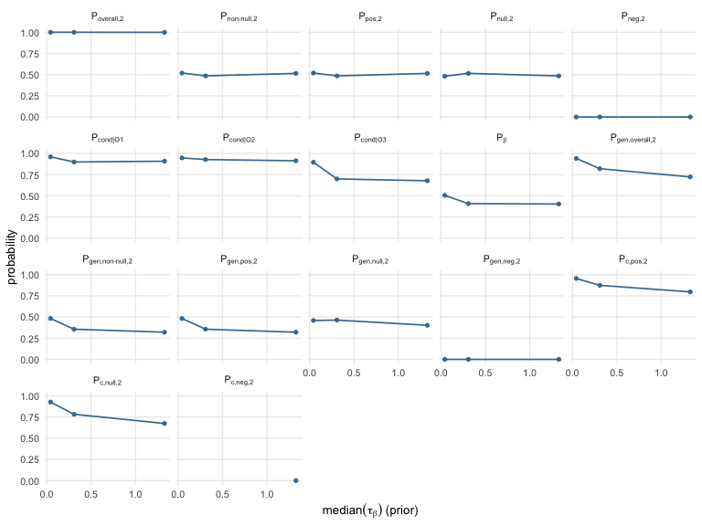

```r
sm <- sens$metrics[sens$metrics$metric %in% metrics_k2, ]
sm$metric <- factor(sm$metric, levels = metrics_k2)
ggplot(sm, aes(prior_med, estimate)) +
  geom_line(color = "#457B9D", linewidth = .6) +
  geom_point(color = "#457B9D", size = 1.2) +
  facet_wrap(~ metric, labeller = as_labeller(lab, label_parsed)) +
  ylim(0, 1) +
  labs(x = expression(median(tau[beta])~"(prior)"), y = "probability") +
  theme_minimal(base_size = 10) + theme(panel.grid.minor = element_blank())
```

# Calibration through simulation

This varies one generative component at a time (Scenario A: $\tau_\beta$; B: $\tau_\alpha$; C: $\tau_\sigma$) and refits many datasets, so it is **compute-heavy**; a tiny `R` and short chains are used here for illustration.

```r
sim <- list(
  beta  = simulate_replicability(res, synthetic_data, vary = "tau_beta",  consensus_level = 2, min_corroborating = 1, R = 10, iter = 500),
  alpha = simulate_replicability(res, synthetic_data, vary = "tau_alpha", consensus_level = 2, min_corroborating = 1, R = 10, iter = 500),
  sigma = simulate_replicability(res, synthetic_data, vary = "tau_sig",   consensus_level = 2, min_corroborating = 1, R = 10, iter = 500)
)
```

```r
show_tbl(sim$beta, caption = "Simulation, Scenario A (effect heterogeneity): metrics with MCSE")
```

Simulation, Scenario A (effect heterogeneity): metrics with MCSE

| level | pctl | metric | value | mcse | n_used |
| --- | --- | --- | --- | --- | --- |
| low | 0.1 | P_overall_2 | 0.998 | 0.001 | 4 |
| low | 0.1 | P_non_null_2 | 0.278 | 0.093 | 4 |
| low | 0.1 | P_pos_2 | 0.278 | 0.093 | 4 |
| low | 0.1 | P_neg_2 | 0.000 | 0.000 | 4 |
| low | 0.1 | P_null_2 | 0.720 | 0.092 | 4 |
| low | 0.1 | P_cond_O1_m1 | 0.693 | 0.138 | 4 |
| low | 0.1 | P_cond_O2_m1 | 0.692 | 0.087 | 4 |
| low | 0.1 | P_cond_O3_m1 | 0.662 | 0.129 | 4 |
| low | 0.1 | P_beta | 0.256 | 0.081 | 4 |
| low | 0.1 | P_gen_overall_2 | 0.877 | 0.030 | 4 |
| low | 0.1 | P_gen_non_null_2 | 0.207 | 0.072 | 4 |
| low | 0.1 | P_gen_pos_2 | 0.207 | 0.072 | 4 |
| low | 0.1 | P_gen_neg_2 | 0.000 | 0.000 | 4 |
| low | 0.1 | P_gen_null_2 | 0.670 | 0.101 | 4 |
| low | 0.1 | P_c_pos_2 | 0.709 | 0.103 | 4 |
| low | 0.1 | P_c_neg_2 | NaN | NA | 4 |
| low | 0.1 | P_c_null_2 | 0.890 | 0.035 | 4 |
| medium | 0.5 | P_overall_2 | 1.000 | NA | 1 |
| medium | 0.5 | P_non_null_2 | 0.118 | NA | 1 |
| medium | 0.5 | P_pos_2 | 0.118 | NA | 1 |
| medium | 0.5 | P_neg_2 | 0.000 | NA | 1 |
| medium | 0.5 | P_null_2 | 0.882 | NA | 1 |
| medium | 0.5 | P_cond_O1_m1 | 0.626 | NA | 1 |
| medium | 0.5 | P_cond_O2_m1 | 0.577 | NA | 1 |
| medium | 0.5 | P_cond_O3_m1 | 0.493 | NA | 1 |
| medium | 0.5 | P_beta | 0.117 | NA | 1 |
| medium | 0.5 | P_gen_overall_2 | 0.909 | NA | 1 |
| medium | 0.5 | P_gen_non_null_2 | 0.072 | NA | 1 |
| medium | 0.5 | P_gen_pos_2 | 0.072 | NA | 1 |
| medium | 0.5 | P_gen_neg_2 | 0.000 | NA | 1 |
| medium | 0.5 | P_gen_null_2 | 0.837 | NA | 1 |
| medium | 0.5 | P_c_pos_2 | 0.615 | NA | 1 |
| medium | 0.5 | P_c_neg_2 | NaN | NA | 1 |
| medium | 0.5 | P_c_null_2 | 0.948 | NA | 1 |
| high | 0.9 | P_overall_2 | 0.419 | 0.255 | 2 |
| high | 0.9 | P_non_null_2 | 0.313 | 0.196 | 2 |
| high | 0.9 | P_pos_2 | 0.313 | 0.196 | 2 |
| high | 0.9 | P_neg_2 | 0.000 | 0.000 | 2 |
| high | 0.9 | P_null_2 | 0.106 | 0.060 | 2 |
| high | 0.9 | P_cond_O1_m1 | 0.002 | 0.002 | 2 |
| high | 0.9 | P_cond_O2_m1 | 1.000 | 0.000 | 2 |
| high | 0.9 | P_cond_O3_m1 | 0.313 | 0.196 | 2 |
| high | 0.9 | P_beta | 0.172 | 0.043 | 2 |
| high | 0.9 | P_gen_overall_2 | 0.150 | 0.095 | 2 |
| high | 0.9 | P_gen_non_null_2 | 0.060 | 0.045 | 2 |
| high | 0.9 | P_gen_pos_2 | 0.060 | 0.045 | 2 |
| high | 0.9 | P_gen_neg_2 | 0.000 | 0.000 | 2 |
| high | 0.9 | P_gen_null_2 | 0.090 | 0.050 | 2 |
| high | 0.9 | P_c_pos_2 | 0.370 | 0.223 | 2 |
| high | 0.9 | P_c_neg_2 | 0.000 | 0.000 | 2 |
| high | 0.9 | P_c_null_2 | 0.112 | 0.066 | 2 |

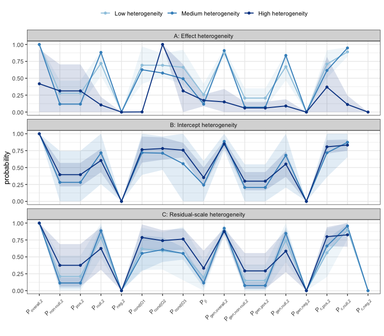

```r
lvlmap <- c(low = "Low heterogeneity", medium = "Medium heterogeneity",
            high = "High heterogeneity")
prep <- function(df, scenario) {
  df <- df[df$metric %in% metrics_k2, c("level","metric","value","mcse")]
  df$level <- lvlmap[as.character(df$level)]; df$scenario <- scenario; df
}
simdf <- rbind(prep(sim$beta,  "A: Effect heterogeneity"),
               prep(sim$alpha, "B: Intercept heterogeneity"),
               prep(sim$sigma, "C: Residual-scale heterogeneity"))
simdf$level  <- factor(simdf$level,
                       levels = c("Low heterogeneity","Medium heterogeneity","High heterogeneity"))
simdf$metric <- factor(simdf$metric, levels = metrics_k2)

ggplot(simdf, aes(metric, value, color = level, group = level)) +
  geom_ribbon(aes(ymin = pmax(0, value - 2*mcse), ymax = pmin(1, value + 2*mcse), fill = level),
              alpha = .15, color = NA) +
  geom_line(linewidth = .7) + geom_point(size = 1.4) +
  facet_wrap(~ scenario, ncol = 1) +
  scale_color_manual(values = c("Low heterogeneity"="#9ECAE1",
                                "Medium heterogeneity"="#4292C6",
                                "High heterogeneity"="#084594")) +
  scale_fill_manual(values = c("Low heterogeneity"="#9ECAE1",
                               "Medium heterogeneity"="#4292C6",
                               "High heterogeneity"="#084594"), guide = "none") +
  scale_x_discrete(labels = function(x) parse(text = lab[x])) +
  scale_y_continuous(limits = c(0, 1), breaks = seq(0, 1, .25)) +
  labs(x = "", y = "probability", color = NULL) +
  theme_bw(base_size = 11) +
  theme(axis.text.x = element_text(angle = 45, hjust = 1), legend.position = "top")
```

# The framework is general

Everything works for any number of studies `S` (pass the effects as a list), any consensus level(s) `k` (a value or a vector), any conditional threshold `m`, and any body of evidence chosen by explicit study indices. For example:

```r
## The metric functions take the study effects as a LIST, so any number of
## studies works. Here: 5 studies, consensus level consensus_level = 3, min_corroborating = 2.
b <- lapply(1:5, function(i) rnorm(4000, 1, 0.4))          # posterior draws, 5 studies
replication_ess(b, generative_beta = rnorm(4000, 1, 0.4), eps = 0.2, consensus_level = 3, min_corroborating = 2)

## fit_replicability() takes a data frame (columns study, x, y), not a list of
## draws, because it fits the models from the raw data.
five_study_data <- do.call(rbind, lapply(1:5, function(s) {
  x <- sample(0:2, 200, replace = TRUE)
  data.frame(study = s, x = x, y = rnorm(200, 8 + 0.5 * x, 2))
}))
res_five_study <- fit_replicability(five_study_data, consensus_level = c(2, 3),
                  retro_target = 5, retro_evidence = c(1, 2, 3, 4),
                  pro_evidence = c(1, 2))
```

# Notes on the data

The paper analyses controlled-access GTEx data, which cannot be redistributed; `synthetic_data` has the same structure so the pipeline runs, but its numbers are illustrative and will not match the paper exactly.